# Lab 4

Meredith Tucker

3/11/2020

```r
defense <- read_excel('cyclonesFootball2019.xlsx', sheet='Defensive')
str(defense)
```

```
## Classes 'tbl_df', 'tbl' and 'data.frame':    502 obs. of  11 variables:
##  $ Name             : chr  "White, Lawrence" "White, Lawrence" "White, Lawrence" "White, Lawrence" ...
##  $ Opponent_Opponent: chr  "UNI" "Iowa" "ULM" "Baylor" ...
##  $ Tackles_Solo     : chr  "4" "4" "3" "4" ...
##  $ Tackles_ASST     : chr  "4" "7" "5" "2" ...
##  $ Tackles_TFL      : chr  "0" "0" "0" "0" ...
##  $ Tackles_Sack     : chr  "0" "0" "0" "0" ...
##  $ Turnover_FF      : chr  "0" "0" "0" "0" ...
##  $ Turnover_FR      : chr  "0" "0" "0" "0" ...
##  $ Turnover_INT     : chr  "0" "0" "1" "0" ...
##  $ Pass_QBH         : chr  "1" "0" "0" "0" ...
##  $ Pass_PB          : chr  "1" "2" "0" "0" ...
```

```r
offense <- read_excel('cyclonesFootball2019.xlsx', sheet='Offensive')
str(offense)
```

```
## Classes 'tbl_df', 'tbl' and 'data.frame':    195 obs. of  12 variables:
##  $ Name             : chr  "Akers, Landen" "Akers, Landen" "Akers, Landen" "Akers, Landen" ...
##  $ Opponent_Opponent: chr  "UNI" "Iowa" "ULM" "Baylor" ...
##  $ Rushing_ATT      : chr  "0" "0" "1" "0" ...
##  $ Rushing_YDS      : chr  "0" "0" "8" "0" ...
##  $ Rushing_TD       : chr  "0" "0" "0" "0" ...
##  $ Receiving_REC    : chr  "1" "0" "0" "0" ...
##  $ Receiving_YDS    : chr  "21" "0" "0" "0" ...
##  $ Receiving_TD     : chr  "0" "0" "0" "0" ...
##  $ Passing_CMP-ATT  : chr  NA NA NA NA ...
##  $ Passing_YDS      : chr  NA NA NA NA ...
##  $ Passing_TD       : chr  NA NA NA NA ...
##  $ Passing_INT      : chr  NA NA NA NA ...
```

```r
biography <- read_excel('cyclonesFootball2019.xlsx', sheet='Biography')
str(biography)
```

```
## Classes 'tbl_df', 'tbl' and 'data.frame':    105 obs. of  7 variables:
##  $ Name      : chr  "Akers, Landen" "Allen, Chase" "Anderson, Ezeriah" "Assalley, Connor" ...
##  $ Position  : chr  "Wide Receiver" "Tight End" "Wide Receiver" "Placekicker" ...
##  $ Height    : chr  "6-0" "6-7" "6-5" "6-0" ...
##  $ Weight    : chr  "188" "245" "204" "195" ...
##  $ Class     : chr  "Redshirt Senior" "Redshirt Senior" "Redshirt Freshman" "Redshirt Senior" ...
##  $ Hometown  : chr  "Cedar Rapids, Iowa" "Nixa, Mo." "Seffner, Fla." "Naperville, Ill." ...
##  $ Highschool: chr  "Washington" "Nixa" "Armwood" "Central" ...
```

# Part One

1.) The player names and opponent names are factors.

```r
defclean <- defense %>%
  mutate_at(c('Name', 'Opponent_Opponent'), factor)

offclean <- offense %>%
  mutate_at(c('Name', 'Opponent_Opponent'), factor)

bioclean <- biography %>%
  mutate_at(c('Name'), factor)
```

2.) All offensive and defensive statistics are numerical. The Weight column in biogrpahy is also numeric. (Hint: look at ?mutate_at if you want to save writing some code).

```r
defclean <- defclean %>%
  mutate_at(c(3,4,5,6,7,8,9,10,11), as.numeric)
offclean <- offclean %>%
  mutate_at(c(3,4,5,6,7,8,9,10,11, 12), as.numeric)
head(defclean)
```

```
## # A tibble: 6 x 11
##   Name  Opponent_Oppone~ Tackles_Solo Tackles_ASST Tackles_TFL Tackles_Sack
##   <fct> <fct>                   <dbl>        <dbl>       <dbl>        <dbl>
## 1 Whit~ UNI                         4            4           0            0
## 2 Whit~ Iowa                        4            7           0            0
## 3 Whit~ ULM                         3            5           0            0
## 4 Whit~ Baylor                      4            2           0            0
## 5 Whit~ TCU                         3            2           1            0
## 6 Whit~ West Virginia               1            1           0            0
## # ... with 5 more variables: Turnover_FF <dbl>, Turnover_FR <dbl>,
## #   Turnover_INT <dbl>, Pass_QBH <dbl>, Pass_PB <dbl>
```

```r
head(offclean)
```

```
## # A tibble: 6 x 12
##   Name  Opponent_Oppone~ Rushing_ATT Rushing_YDS Rushing_TD Receiving_REC
##   <fct> <fct>                  <dbl>       <dbl>      <dbl>         <dbl>
## 1 Aker~ UNI                        0           0          0             1
## 2 Aker~ Iowa                       0           0          0             0
## 3 Aker~ ULM                        1           8          0             0
## 4 Aker~ Baylor                     0           0          0             0
## 5 Aker~ TCU                        0           0          0             1
## 6 Aker~ West Virginia              0           0          0             0
## # ... with 6 more variables: Receiving_YDS <dbl>, Receiving_TD <dbl>,
## #   `Passing_CMP-ATT` <dbl>, Passing_YDS <dbl>, Passing_TD <dbl>,
## #   Passing_INT <dbl>
```

3.) Change the Height column in biogrpahy into numeric. (Hint: Use a unit that works well)

```r
bioclean <- bioclean %>%
  separate(Height, c('Feet', 'Inches'), sep='-', convert=TRUE) %>% mutate(cm = (12*Feet + Inches) *2.54)
head(bioclean)
```

```
## # A tibble: 6 x 9
##   Name      Position    Feet Inches Weight Class    Hometown    Highschool    cm
##   <fct>     <chr>      <int>  <int> <chr>  <chr>    <chr>       <chr>      <dbl>
## 1 Akers, L~ Wide Rece~     6      0 188    Redshir~ Cedar Rapi~ Washington  183.
## 2 Allen, C~ Tight End      6      7 245    Redshir~ Nixa, Mo.   Nixa        201.
## 3 Anderson~ Wide Rece~     6      5 204    Redshir~ Seffner, F~ Armwood     196.
## 4 Assalley~ Placekick~     6      0 195    Redshir~ Naperville~ Central     183.
## 5 Azunna, ~ Defensive~     6      0 190    Redshir~ Grand Prai~ Lake Ridge  183.
## 6 Bailey, ~ Defensive~     6      3 235    Redshir~ Clarksdale~ Clarksdale  190.
```

# Part 2

For the following questions, work on the cleaned data frames defClean, offClean, and bioClean.

1.) Reformat the defClean data frame into a tidy format using pivot_longer. The type of statistic (Tackles_Solo, Tackles_ASST, etc) is added as a new key column named Statistic.

```r
longdefclean <- defclean %>%
  pivot_longer(c(3:11), names_to='Statistic', values_to='Score')
```

2.) Create a histogram for each defensive statistic. Use facet_wrap to draw all histograms in a single plot. What defensive skills are rare?

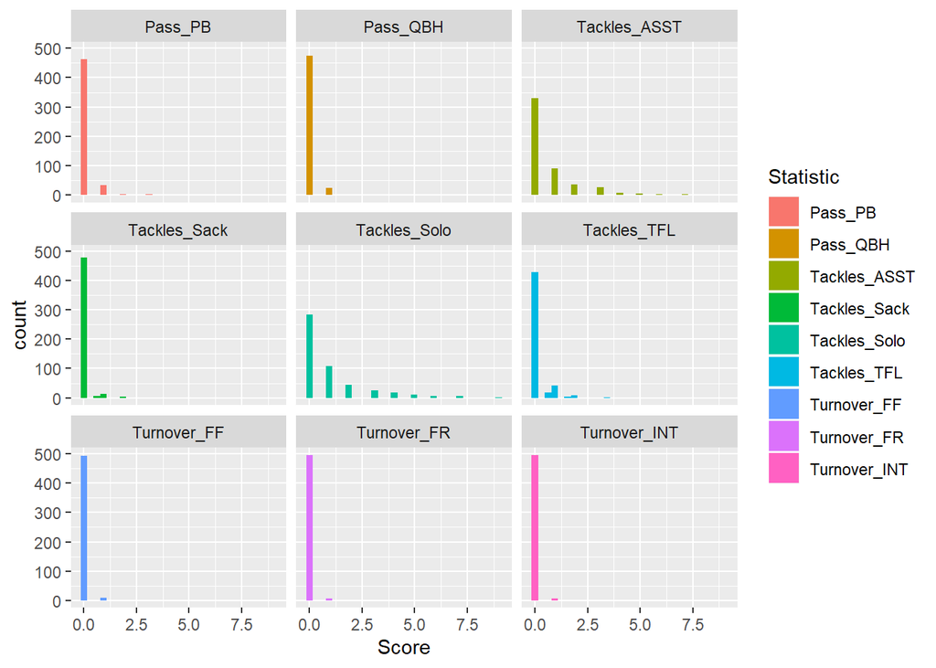

```r
longdefclean %>%
  ggplot(aes(x=Score, fill=Statistic)) + geom_histogram() + facet_wrap(~Statistic)
```

3.) Did ISU have better defense against West Virginia or Kansas State? Answer this question by creating a scatterplot with x-axis being the number of solo tackles (by each player) against West Virginia, and y-axis being that against Kansas State. A large number of solo tackles indicates good defense.

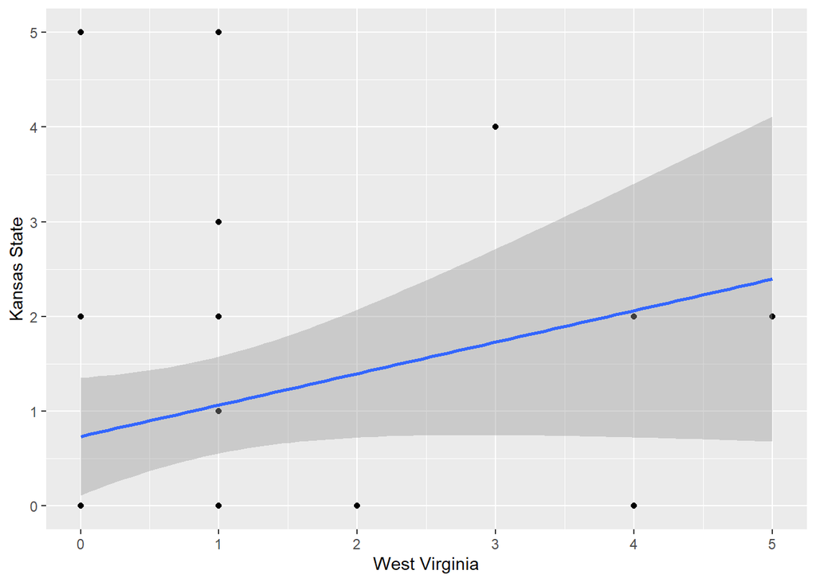

```r
longdefclean %>%
  filter(Opponent_Opponent == 'West Virginia' | Opponent_Opponent =='Kansas State') %>%
  filter(Statistic == 'Tackles_Solo') %>%
  group_by(Name) %>%
  mutate(Count = n()) %>%
  filter(Count== 2) %>%
  ungroup() %>%
  pivot_wider(names_from = Opponent_Opponent, values_from = Score) %>%
  ggplot(aes(x=`West Virginia`, y=`Kansas State`)) + geom_point() + stat_smooth(method=lm)
```

West Virginia has more Solo Tackles than Kansas State. Iowa State had a better defense against West Virginia than against Kansas State.